# CKiD research project

Benjamin Matta, MD

December 22, 2018

# Do higher cumulative antihypertensive doses result in better blood pressure (BP) control in children with chronic kidney disease (CKD)?

## Background

Hypertension is a major risk factor for CKD progression as well as cardiovascular and neurocognitive comorbidities. The prevalence of uncontrolled hypertension in children with CKD is high, despite a majority of whom are taking antihypertensive medications. A recent study of the pediatric CKD population by Barletta, et al (2017) demonstrated the increasing prevalence of masked hypertension over the last 10 years in the CKiD study cohort, suggesting undertreatment. To our knowledge, no studies have examined the influence of antihypertensive dosing on BP control in the pediatric CKD population. This study proposes a new method to quantitatively analyze the cumulative dose of antihypertensive medications and its effect on blood pressure control. In addition, recently published BP percentiles (AAP 2017) were used in determining BP classification used for the analysis.

### Definition of Drug Dose Index (DDI)

- The DDI is a property of every drug dose and depends on
  - the medication
  - the maximum dose based on the patient’s age, weight and eGFR
- The DDI is the ratio of the patient’s dose to the maximum dose appropriate for that patient, up to a value of 1

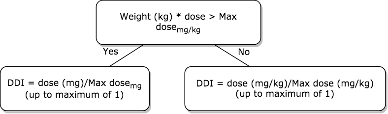

#### cumulative DDI = sum of all DDI for each agent taken by the patient

## Objective

To determine the role of antihypertensive dosing, as defined by the cumulative DDI, on BP control in children with CKD. LVMI percentile as a measure of target organ damage from chronic hypertension, was also evaluated as a secondary outcome to determine its relationship with cummulative DDI.

## Hypothesis

If hypertension is undertreated due to inadequate dose of BP medications, patients with hypertension and LVH will have the same or lower cumulative doses compared to those with normal blood pressure.

## Methods

This study is a retrospective analysis of data obtained from the CKiD database via public request from the NIDDK. The third visit was used for the analysis, which is the first visit including physical exam, ambulatory blood pressure monitor (ABPM), echocardiogram, and patient medications. * systolic and diastolic BP percentiles were calculated based on the methods published in Rosner B, et al. (2008). BP z-score was determined from BP percentile using the quantile function. + BP classification was then determined based on casual BP and ambulatory blood pressure monitoring study results, as described by Samuels, J et al (2009), and shown below

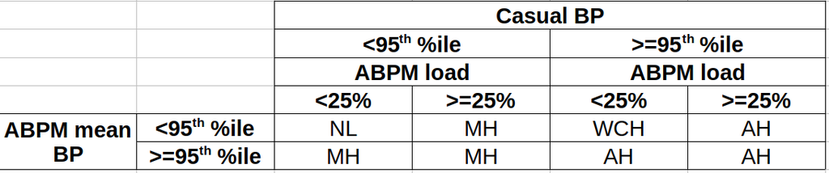

**NL = normal BP, WCH = white-coat hypertension, MH = masked hypertension, AH = ambulatory hypertension**

- LVMI percentile was calculated based on normative tables published by Khoury PR, et al (2009).
- LVH was defined as those with LVMI >= 95th percentile
- Patient characteristics were also considered as possible covariates:
- number of BP agents at baseline visit
- age (years)
- sex
- race
- CKD stage
- eGFR based on full CkiD gfr equation
  $$eGFR = 39.8 \times \left ( \frac{ht(m)}{Scr} \right )^{0.456} \times \left( \frac{1.8}{cysC} \right )^{0.418}\times \left ( \frac{30}{BUN} \right )^{0.079}\times 1.076^{male}\times \left ( \frac{ht(m)}{1.4} \right )^{0.179}$$
- time of CKD onset (yrs)
- Primary CKD diagnosis (glomerular or non-glomerular)
- Degree of proteinuria (urine protein:creatinine ratio (mg/mg Cr), and categorical (normal;mild;moderate;severe))
- BMI z-score
- total household income
- due to positively skewed distribution of cumulative DDI, all statistical tests were performed on ln(cumulative DDI).
- all group comparisons report mean(SD) for cumulative DDI
- p-values are based on
  - t-test for dichotomous factors (eg, sex - male or female)
  - ANOVA for factors with >2 levels (eg, CKD stage 2-5)
  - chi-square test when both variables are categorical

### The study population

#### Inclusion criteria

- entered into CKiD study
- taking at least *one* antihypertensive medication
- measured BP
- known age, gender and height
- successful ABPM study

#### Exclusion criteria

- missing BP medication details:
  - daily dose
  - daily frequency
  - weight
- white-coat hypertension (n=5)

## Results

### Study population characteristics (n=255)

Loading objects: test medsum_full.old ### Data Frame Summary  
**test.cohort**  
**Dimensions:** 255 x 18  
**Duplicates:** 0

| No | Variable | Stats / Values | Freqs (% of Valid) | Text Graph | Valid | Missing |
| --- | --- | --- | --- | --- | --- | --- |
| 1 | age [numeric] | Mean (Std.Dev) :12.85 (3.68) min < med < max: 3.01 < 13.04 < 19.45 IQR (CV) :5.98 (0.29) | 229 distinct values |  | 255 (100%) | 0 (0%) |
| 2 | age.factor [ordered, factor] | 1. (0,10] 2. (10,13] 3. (13,16] 4. (16,Inf] | 63 (24.7%) 62 (24.3%) 67 (26.3%) 63 (24.7%) | IIII IIII IIIII IIII | 255 (100%) | 0 (0%) |
| 3 | MALE1FE0 [numeric] | Mean (Std.Dev) :0.59 (0.49) min < med < max: 0 < 1 < 1 mode: | 0 : 105 (41.2%) 1 : 150 (58.8%) | IIIIIIII IIIIIIIIIII | 255 (100%) | 0 (0%) |
| 4 | CKD_stage [ordered, factor] | 1. 1 2. 2 3. 3 4. 4 5. 5 | 1 ( 0.4%) 35 (13.7%) 143 (56.1%) 63 (24.7%) 13 ( 5.1%) | II IIIIIIIIIII IIII I | 255 (100%) | 0 (0%) |
| 5 | CKDONST [numeric] | Mean (Std.Dev) :-8.28 (4.84) min < med < max: -17.5 < -8.51 < -0.08 IQR (CV) :8 (-0.58) | 248 distinct values |  | 250 (98.04%) | 5 (1.96%) |
| 6 | n_agents [integer] | Mean (Std.Dev) :1.25 (0.56) min < med < max: 1 < 1 < 4 IQR (CV) :0 (0.45) | 1 : 203 (79.6%) 2 : 42 (16.5%) 3 : 7 ( 2.8%) 4 : 3 ( 1.2%) | IIIIIIIIIIIIIII III | 255 (100%) | 0 (0%) |
| 7 | BPclass.factor [ordered, factor] | 1. NL 2. WCH 3. MH 4. AH | 105 (41.2%) 0 ( 0.0%) 105 (41.2%) 45 (17.6%) | IIIIIIII IIIIIIII III | 255 (100%) | 0 (0%) |
| 8 | SBPZAGH2017 [numeric] | Mean (Std.Dev) :0.35 (1.07) min < med < max: -2.33 < 0.3 < 2.37 IQR (CV) :1.38 (3.08) | 245 distinct values |  | 255 (100%) | 0 (0%) |
| 9 | DBPPCTAGH2017 [numeric] | Mean (Std.Dev) :57.5 (28.22) min < med < max: 0.99 < 55.94 < 99.1 IQR (CV) :50.82 (0.49) | 248 distinct values |  | 255 (100%) | 0 (0%) |
| 10 | LVMIp [numeric] | Mean (Std.Dev) :56.24 (30.25) min < med < max: 10 < 50 < 95 IQR (CV) :65 (0.54) | 10 : 41 (16.1%) 25 : 37 (14.5%) 50 : 57 (22.4%) 75 : 55 (21.6%) 90 : 29 (11.4%) 95 : 36 (14.1%) | III II IIII IIII II II | 255 (100%) | 0 (0%) |
| 11 | Upc [numeric] | Mean (Std.Dev) :0.94 (1.44) min < med < max: 0.02 < 0.42 < 9.6 IQR (CV) :0.87 (1.53) | 218 distinct values |  | 255 (100%) | 0 (0%) |
| 12 | Upc.factor [ordered, factor] | 1. normal 2. mild 3. moderate 4. severe | 141 (55.3%) 37 (14.5%) 48 (18.8%) 29 (11.4%) | IIIIIIIIIII II III II | 255 (100%) | 0 (0%) |
| 13 | BMIz [numeric] | Mean (Std.Dev) :0.41 (1.14) min < med < max: -2.95 < 0.4 < 2.93 IQR (CV) :1.73 (2.79) | 250 distinct values |  | 255 (100%) | 0 (0%) |
| 14 | BMI.factor [ordered, factor] | 1. Underweight 2. Normal weight 3. Overweight 4. Obese+Severely Obese | 7 ( 2.8%) 168 (65.9%) 37 (14.5%) 43 (16.9%) | IIIIIIIIIIIII II III | 255 (100%) | 0 (0%) |
| 15 | GNGDIAG [integer] | Mean (Std.Dev) :2.69 (0.71) min < med < max: 1 < 3 < 4 IQR (CV) :1 (0.26) | 1 : 12 ( 4.7%) 2 : 79 (31.0%) 3 : 140 (54.9%) 4 : 24 ( 9.4%) | IIIIII IIIIIIIIII I | 255 (100%) | 0 (0%) |
| 16 | GHTOTINC [integer] | Mean (Std.Dev) :5.68 (3.07) min < med < max: -9 < 7 < 8 IQR (CV) :4 (0.54) | 12 distinct values |  | 255 (100%) | 0 (0%) |
| 17 | RACE [integer] | Mean (Std.Dev) :2.21 (2.23) min < med < max: 1 < 1 < 8 IQR (CV) :1 (1.01) | 1 : 176 (69.0%) 2 : 25 ( 9.8%) 3 : 4 ( 1.6%) 4 : 2 ( 0.8%) 5 : 9 ( 3.5%) 6 : 15 ( 5.9%) 7 : 9 ( 3.5%) 8 : 15 ( 5.9%) | IIIIIIIIIIIII I I I | 255 (100%) | 0 (0%) |
| 18 | sum_DDI [numeric] | Mean (Std.Dev) :0.57 (0.52) min < med < max: 0 < 0.4 < 3 IQR (CV) :0.6 (0.91) | 186 distinct values |  | 255 (100%) | 0 (0%) |

### 1) Overall summary (all patients, n=255)

Summary: all patients (n=255)

| BPclass.factor | Avg | SD | Min | Max | Mean BP agents | N |
| --- | --- | --- | --- | --- | --- | --- |
| NL | 0.50 | 0.50 | 0.0167 | 3.0 | 1.14 | 105 |
| MH | 0.55 | 0.48 | 0.0553 | 2.0 | 1.23 | 105 |
| AH | 0.78 | 0.60 | 0.0035 | 2.8 | 1.58 | 45 |

#### Compare cumulative DDI between different BP status groups

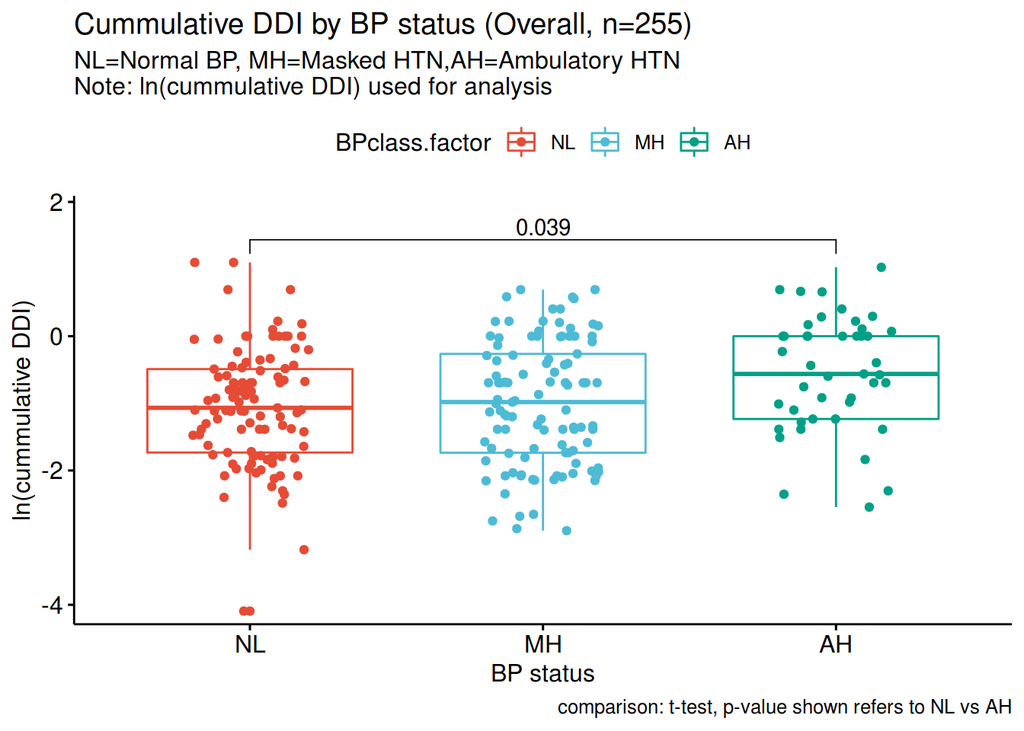

Comparisons between BP status: Overall (n=255)

.y.

group1

group2

p.format

p.signif

method

sum_DDI.ln

NL

MH

0.653

ns

T-test

sum_DDI.ln

NL

AH

0.039

T-test

sum_DDI.ln

MH

AH

0.079

ns

T-test

Comparisons between BP status: Overall (n=255)

| .y. | p.format | p.signif | method |
| --- | --- | --- | --- |
| sum_DDI.ln | 0.053 | ns | Anova |

#### Interpretation:

- The cumulative DDI is significantly lower in the NL vs AH group
  - mean(SD) = 0.5(0.5) vs 0.78(0.6), p=0.04
- ANOVA: Comparing mean cumulative DDI between all groups, p-value = 0.053
- The average cumulative DDI of the MH group does not significantly differ from either the NL or the AH group, however is closer to the NL group
  - This may suggest undertreatment, in terms of antihypertensive dosing, in the MH group vs the NL group

### 2) Subgroup: Primary CKD diagnosis: Non-glomerular only, n=164 (Cumulative DDI by BP status)

Subgroup Summary (non-glomerular): cumulative DDI

| BPclass.factor | Avg | SD | Min | Max | Mean BP agents | N |
| --- | --- | --- | --- | --- | --- | --- |
| NL | 0.44 | 0.37 | 0.042 | 2.0 | 1.09 | 64 |
| MH | 0.49 | 0.43 | 0.057 | 2.0 | 1.18 | 73 |
| AH | 0.59 | 0.46 | 0.078 | 1.9 | 1.44 | 27 |

#### Subgroup (non-glomerular): Compare cumulative DDI between different BP status groups

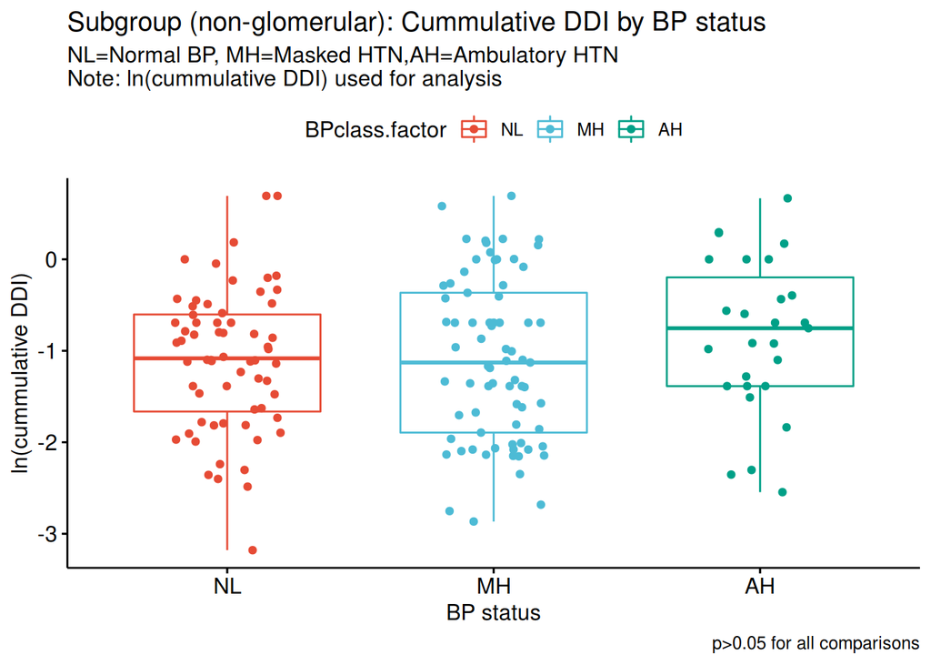

Comparisons between BP status: non-glomerular (n=164)

| .y. | p.format | p.signif | method |
| --- | --- | --- | --- |
| sum_DDI.ln | 0.34 | ns | Anova |

Comparisons between BP status: non-glomerular (n=164)

| .y. | group1 | group2 | p.format | p.signif | method |
| --- | --- | --- | --- | --- | --- |
| sum_DDI.ln | NL | MH | 1.00 | ns | T-test |
| sum_DDI.ln | NL | AH | 0.18 | ns | T-test |
| sum_DDI.ln | MH | AH | 0.19 | ns | T-test |

#### Interpretation:

- The cumulative DDI similar among all BP status groups. This suggests a possible opportunity to improve BP control in the non-glomerular group with hypertension.

### 3) Subgroup: BMI categories (Cumulative DDI by BP status)

#### (Underweight=0-5th %ile, Normal=5-85th %ile, Overweight=85-95th %ile, Obese+Severely Obese>95th %ile)

Subgroup Summary (BMI categories): cumulative DDI

| BMI.factor | BPclass.factor | Avg | SD | Min | Max | Mean BP agents | N |
| --- | --- | --- | --- | --- | --- | --- | --- |
| Underweight | NL | 0.29 | 0.23 | 0.1502 | 0.56 | 1.00 | 3 |
| Underweight | MH | 0.16 | 0.10 | 0.0684 | 0.27 | 1.00 | 3 |
| Underweight | AH | 1.00 | NA | 1.0000 | 1.00 | 1.00 | 1 |
| Normal weight | NL | 0.53 | 0.50 | 0.0416 | 3.00 | 1.13 | 68 |
| Normal weight | MH | 0.56 | 0.52 | 0.0553 | 2.00 | 1.22 | 67 |
| Normal weight | AH | 0.69 | 0.52 | 0.0035 | 1.95 | 1.55 | 33 |
| Overweight | NL | 0.42 | 0.31 | 0.1306 | 1.25 | 1.12 | 16 |
| Overweight | MH | 0.51 | 0.35 | 0.0638 | 1.20 | 1.39 | 18 |
| Overweight | AH | 0.86 | 0.31 | 0.5000 | 1.07 | 1.33 | 3 |
| Obese+Severely Obese | NL | 0.49 | 0.67 | 0.0167 | 3.00 | 1.22 | 18 |
| Obese+Severely Obese | MH | 0.59 | 0.43 | 0.0569 | 1.50 | 1.12 | 17 |
| Obese+Severely Obese | AH | 1.07 | 0.92 | 0.0951 | 2.79 | 1.88 | 8 |

#### Subgroup (BMI categories): Compare cumulative DDI between different BP status groups within BMI categories

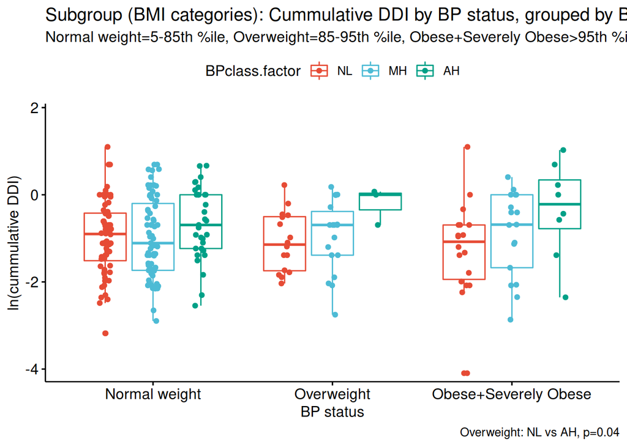

Comparisons between BP status: BMI categories

| BMI.factor | .y. | p.format | p.signif | method |
| --- | --- | --- | --- | --- |
| Normal weight | sum_DDI.ln | 0.58 | ns | Anova |
| Overweight | sum_DDI.ln | 0.19 | ns | Anova |
| Obese+Severely Obese | sum_DDI.ln | 0.15 | ns | Anova |

Comparisons between BP status: BMI categories

BMI.factor

.y.

group1

group2

p.format

p.signif

method

Normal weight

sum_DDI.ln

NL

MH

0.947

ns

T-test

Normal weight

sum_DDI.ln

NL

AH

0.421

ns

T-test

Normal weight

sum_DDI.ln

MH

AH

0.407

ns

T-test

Overweight

sum_DDI.ln

NL

MH

0.626

ns

T-test

Overweight

sum_DDI.ln

NL

AH

0.038

T-test

Overweight

sum_DDI.ln

MH

AH

0.060

ns

T-test

Obese+Severely Obese

sum_DDI.ln

NL

MH

0.334

ns

T-test

Obese+Severely Obese

sum_DDI.ln

NL

AH

0.080

ns

T-test

Obese+Severely Obese

sum_DDI.ln

MH

AH

0.258

ns

T-test

#### Interpretation:

There are no signfificant differences in cumulative DDI by BP status among all BMI categories, except for:

- Among *overweight* children, the average cumulative DDI is significantly higher in the AH vs NL group
  - mean(SD) = 0.86(0.31) vs 0.42(0.31), p=0.04

### 3) Subgroup: CKD stages (Cumulative DDI by BP status)

Subgroup Summary (CKD stages): cumulative DDI

| CKD_stage | BPclass.factor | Avg | SD | Min | Max | Mean BP agents | N |
| --- | --- | --- | --- | --- | --- | --- | --- |
| 1 | AH | 1.93 | NA | 1.9349 | 1.9 | 4.00 | 1 |
| 2 | NL | 0.82 | 0.83 | 0.0167 | 3.0 | 1.38 | 13 |
| 2 | MH | 0.58 | 0.38 | 0.1166 | 1.2 | 1.22 | 9 |
| 2 | AH | 0.71 | 0.42 | 0.2210 | 1.5 | 1.46 | 13 |
| 3 | NL | 0.49 | 0.48 | 0.0416 | 3.0 | 1.13 | 60 |
| 3 | MH | 0.57 | 0.50 | 0.0553 | 2.0 | 1.21 | 61 |
| 3 | AH | 0.63 | 0.49 | 0.0035 | 1.9 | 1.45 | 22 |
| 4 | NL | 0.36 | 0.27 | 0.0833 | 1.1 | 1.04 | 25 |
| 4 | MH | 0.47 | 0.46 | 0.0569 | 1.8 | 1.22 | 32 |
| 4 | AH | 1.28 | 0.98 | 0.0951 | 2.8 | 2.17 | 6 |
| 5 | NL | 0.47 | 0.40 | 0.1250 | 1.2 | 1.14 | 7 |
| 5 | MH | 0.86 | 0.24 | 0.5848 | 1.0 | 1.67 | 3 |
| 5 | AH | 0.72 | 0.49 | 0.1593 | 1.0 | 1.00 | 3 |

#### 4) Subgroup (CKD stages): Compare cumulative DDI between different BP status groups within each CKD stage subgroup

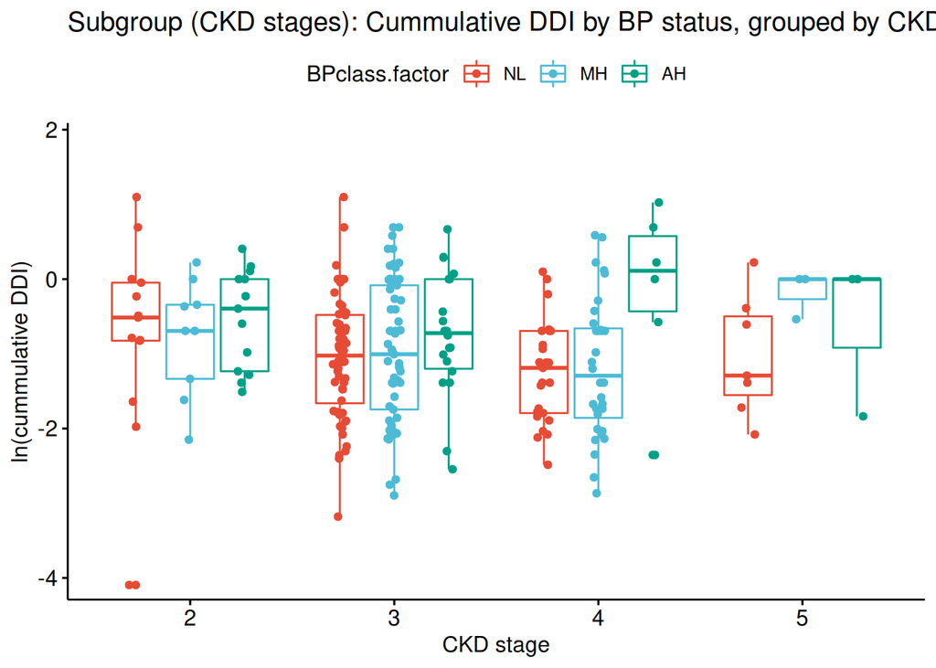

Comparisons between BP status: CKD stages

CKD_stage

.y.

p.format

p.signif

method

2

sum_DDI.ln

0.810

ns

Anova

3

sum_DDI.ln

0.870

ns

Anova

4

sum_DDI.ln

0.024

Anova

5

sum_DDI.ln

0.325

ns

Anova

Comparisons between BP status: CKD stages

CKD_stage

.y.

group1

group2

p.format

p.signif

method

2

sum_DDI.ln

NL

MH

0.940

ns

T-test

2

sum_DDI.ln

NL

AH

0.616

ns

T-test

2

sum_DDI.ln

MH

AH

0.461

ns

T-test

3

sum_DDI.ln

NL

MH

0.678

ns

T-test

3

sum_DDI.ln

NL

AH

0.707

ns

T-test

3

sum_DDI.ln

MH

AH

0.876

ns

T-test

4

sum_DDI.ln

NL

MH

0.755

ns

T-test

4

sum_DDI.ln

NL

AH

0.080

ns

T-test

4

sum_DDI.ln

MH

AH

0.097

ns

T-test

5

sum_DDI.ln

NL

MH

0.042

T-test

5

sum_DDI.ln

NL

AH

0.579

ns

T-test

5

sum_DDI.ln

MH

AH

0.558

ns

T-test

#### Interpretation:

In the CKD stage 4 group, the cumulative DDI in the NL and MH groups are relatively low compared to that of the AH group. The corresponding ANOVA for CKD stage 4 was significant (p=0.024).

- this may suggest that patients with CKD stage 4 and MH are undertreated
- alternatively other factors may explain their BP status, despite having similar cumulative DDI to the NL group with CKD stage 4.

### 5) Subgroup: Age groups (Cumulative DDI by BP status)

#### (<10 years old, 10-13 yrs, 13-16yrs, >16yrs)

Subgroup Summary (age groups): cumulative DDI

| age.factor | BPclass.factor | Avg | SD | Min | Max | Mean BP agents | N |
| --- | --- | --- | --- | --- | --- | --- | --- |
| (0,10] | NL | 0.43 | 0.38 | 0.1066 | 2.0 | 1.17 | 23 |
| (0,10] | MH | 0.46 | 0.46 | 0.0569 | 2.0 | 1.16 | 25 |
| (0,10] | AH | 0.73 | 0.50 | 0.0951 | 1.9 | 1.53 | 15 |
| (10,13] | NL | 0.49 | 0.41 | 0.0416 | 2.0 | 1.06 | 33 |
| (10,13] | MH | 0.65 | 0.53 | 0.1171 | 1.8 | 1.23 | 22 |
| (10,13] | AH | 0.50 | 0.28 | 0.2210 | 1.0 | 1.43 | 7 |
| (13,16] | NL | 0.45 | 0.33 | 0.0167 | 1.1 | 1.11 | 28 |
| (13,16] | MH | 0.45 | 0.42 | 0.0553 | 1.8 | 1.16 | 31 |
| (13,16] | AH | 0.75 | 0.38 | 0.2500 | 1.2 | 1.62 | 8 |
| (16,Inf] | NL | 0.65 | 0.84 | 0.0833 | 3.0 | 1.29 | 21 |
| (16,Inf] | MH | 0.65 | 0.48 | 0.0704 | 2.0 | 1.37 | 27 |
| (16,Inf] | AH | 0.96 | 0.84 | 0.0035 | 2.8 | 1.67 | 15 |

#### 5) Subgroup (age groups): Compare cumulative DDI between different BP status groups within each age subgroup

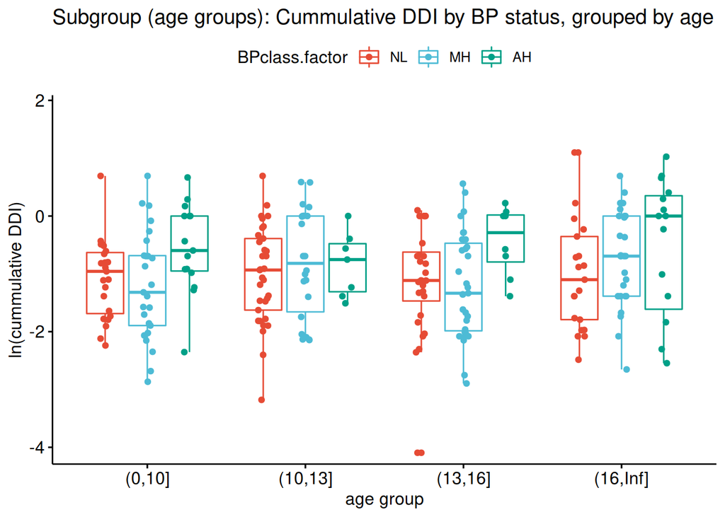

Comparisons between BP status: age groups

| age.factor | .y. | p.format | p.signif | method |
| --- | --- | --- | --- | --- |
| (0,10] | sum_DDI.ln | 0.052 | ns | Anova |
| (10,13] | sum_DDI.ln | 0.660 | ns | Anova |
| (13,16] | sum_DDI.ln | 0.101 | ns | Anova |
| (16,Inf] | sum_DDI.ln | 0.733 | ns | Anova |

Comparisons between BP status: age groups

age.factor

.y.

group1

group2

p.format

p.signif

method

(0,10]

sum_DDI.ln

NL

MH

0.610

ns

T-test

(0,10]

sum_DDI.ln

NL

AH

0.041

T-test

(0,10]

sum_DDI.ln

MH

AH

0.024

T-test

(10,13]

sum_DDI.ln

NL

MH

0.418

ns

T-test

(10,13]

sum_DDI.ln

NL

AH

0.490

ns

T-test

(10,13]

sum_DDI.ln

MH

AH

0.943

ns

T-test

(13,16]

sum_DDI.ln

NL

MH

0.737

ns

T-test

(13,16]

sum_DDI.ln

NL

AH

0.024

T-test

(13,16]

sum_DDI.ln

MH

AH

0.011

T-test

(16,Inf]

sum_DDI.ln

NL

MH

0.341

ns

T-test

(16,Inf]

sum_DDI.ln

NL

AH

0.696

ns

T-test

(16,Inf]

sum_DDI.ln

MH

AH

0.898

ns

T-test

#### Interpretation:

In young kids (3-10yrs), cummulative DDI is significantly higher in AH vs NL and AH vs MH.

In adolescents (13-16yrs), the findings are similar.

ANOVA did not show any significant differences in cumulative DDI between age subgroups, based on BP status

### 6) Subgroup: Number of antihypertensive agents (Cumulative DDI by BP status)

Subgroup Summary (# BP agents): cumulative DDI

| n_agents | BPclass.factor | Avg | SD | Min | Max | N |
| --- | --- | --- | --- | --- | --- | --- |
| 1 | NL | 0.40 | 0.27 | 0.0416 | 1.0 | 92 |
| 1 | MH | 0.37 | 0.28 | 0.0553 | 1.0 | 83 |
| 1 | AH | 0.52 | 0.35 | 0.0035 | 1.0 | 28 |
| 2 | NL | 0.91 | 0.66 | 0.0167 | 2.0 | 11 |
| 2 | MH | 1.24 | 0.48 | 0.5000 | 2.0 | 20 |
| 2 | AH | 1.03 | 0.54 | 0.2913 | 2.0 | 11 |
| 3 | NL | 3.00 | 0.00 | 3.0000 | 3.0 | 2 |
| 3 | MH | 1.10 | 0.14 | 1.0000 | 1.2 | 2 |
| 3 | AH | 0.77 | 0.36 | 0.5625 | 1.2 | 3 |
| 4 | AH | 2.22 | 0.49 | 1.9349 | 2.8 | 3 |

#### 6) Subgroup (# BP agents): Compare cumulative DDI between different BP status groups within each stratum

[figure not shown]

Comparisons between BP status: # BP agents

[output not shown]

Comparisons between BP status: # BP agents

n_agents.factor

.y.

group1

group2

p.format

p.signif

method

1

sum_DDI.ln

NL

MH

0.242

ns

T-test

1

sum_DDI.ln

NL

AH

0.628

ns

T-test

1

sum_DDI.ln

MH

AH

0.309

ns

T-test

2

sum_DDI.ln

NL

MH

0.138

ns

T-test

2

sum_DDI.ln

NL

AH

0.397

ns

T-test

2

sum_DDI.ln

MH

AH

0.244

ns

T-test

3

sum_DDI.ln

NL

MH

0.057

ns

T-test

3

sum_DDI.ln

NL

AH

0.029

T-test

3

sum_DDI.ln

MH

AH

0.233

ns

T-test

#### Interpretation:

#### Subgroup differences based on BP status

- The following analysis was done to determine if there are significant differences in the distribution of BP status within each subgroup
  - Primary CKD diagnosis (glomerular vs non-glomerular): chi-squared test, p=0.35
  - BMI z-score: ANOVA, p=0.91
  - eGFR: ANOVA, p=0.044
  - age (yrs): ANOVA, p=0.88
  - num BP agents: chi-squared test, p=5.110^{-4}